# 1-1 CAPSTONE-Copy1

```python
import pandas as pd
import numpy as np
import matplotlib.pyplot as plt
import seaborn as sns
```

Medical Marijuana & CBD: Evidence of Statements!

When it comes to Medical Marijuana, there's been a rise in the curiosity surrounding the healing qualities of marijuana, which has resulted in more people using it for health purposes and the creation of programs tailored to each state's medical cannabis laws. Marijuana is legal in 33 states and Washington, D.C.

Part of the reason for the scarcity of studies involving humans is that cannabis is still classified as a schedule 1 substance by the US federal government. Even though some states in the US have legalized it, there are still numerous bureaucratic hurdles and legal challenges that prevent researchers from examining the potential health benefits of marijuana for people.

The goal of this project is to investigate and examine the specific uses of medical marijuana that have proven to be effective. This data set is obtained from Kaggle website.

Into to dataframe

```python
c_b = pd.read_csv("c_b.csv")
c_b.head()
```

|  | health condition | alternate name | health condition.1 | evidence score 0 = harmful \n1 = no / insufficient evidence\n6 = strong | popular interest | Number of citations on Google Scholar (2000-2017) search format: condition+cannabis | CBD | simple English notes | notes | link | other International review board or metastudy | individual study | main study source name | other sources |
| --- | --- | --- | --- | --- | --- | --- | --- | --- | --- | --- | --- | --- | --- | --- |
| 0 | ADD/ADHD | NaN | mental health | 1 | 458000 | 824 | CBD | Animal studies show improved social behaviour ... | Pretreatment with the phytocannabinoid cannabi... | http://journals.sagepub.com/doi/abs/10.1177/02... | NaN | NaN | Journal of Psychopharmacology | NaN |
| 1 | Adolescence | NaN | neurological | 0 | 982000 | 103000 | NaN | Use during teenage years appears to affect imp... | In one large population study, cannabis use, b... | https://www.frontiersin.org/articles/10.3389/f... | https://ajp.psychiatryonline.org/doi/10.1176/a... | https://www.ncbi.nlm.nih.gov/pubmed/30408351 | American Journal of Psychiatry, Frontiers in P... | NaN |
| 2 | AIDS-related weight loss | NaN | immune system | 4 | 460000 | 29500 | NaN | One small study (participants = 139) of AIDS p... | Cochrane claims: 'evidence for the efficacy an... | http://onlinelibrary.wiley.com/doi/10.1002/146... | http://www.sciencedirect.com/science/article/p... | NaN | Cochrane, Journal of Ethnopharmacology, NAP | NaN |
| 3 | ALS | Amyotrophic Lateral Sclerosis, Lou Gehrig's Di... | neurological | 2 | 505000 | 1420 | NaN | One very small study (13 patients) resulting i... | Although the small number of people [13] with ... | http://journals.sagepub.com/doi/abs/10.1177/10... | NaN | NaN | American Journal of Hospice and Palliative Med... | NaN |
| 4 | Alzheimer’s | NaN | neurological | 1 | 524000 | 19200 | CBD | No human studies yet. | No human studies yet. A review of in-vitro and... | https://www.ncbi.nlm.nih.gov/pmc/articles/PMC5... | NaN | NaN | Frontiers in Pharmacology | NaN |

```python
c_b.info()
```

```
<class 'pandas.core.frame.DataFrame'>
RangeIndex: 69 entries, 0 to 68
Data columns (total 14 columns):
 #   Column                                                                               Non-Null Count  Dtype
---  ------                                                                               --------------  -----
 0   health condition                                                                     69 non-null     object
 1   alternate name                                                                       5 non-null      object
 2   health condition.1                                                                   69 non-null     object
 3   evidence score 0 = harmful
1 = no / insufficient evidence
6 = strong                69 non-null     int64
 4   popular interest                                                                     69 non-null     int64
 5   Number of citations on Google Scholar (2000-2017) search format: condition+cannabis  69 non-null     int64
 6   CBD                                                                                  20 non-null     object
 7   simple English notes                                                                 69 non-null     object
 8   notes                                                                                69 non-null     object
 9   link                                                                                 68 non-null     object
 10  other International review board or metastudy                                        12 non-null     object
 11  individual study                                                                     6 non-null      object
 12  main study source name                                                               69 non-null     object
 13  other sources                                                                        3 non-null      object
dtypes: int64(3), object(11)
memory usage: 7.7+ KB
```

As you can see the data set has several columns: health condition: The medical condition under consideration. alternate name: Alternate names for the medical condition, if any. health condition.1: A general category for the health condition. evidence score 0 = harmful \n1 = no / insufficient evidence\n6 = strong: A score representing the strength of the evidence for the efficacy of cannabis or CBD in treating the condition. A score of 0 indicates that cannabis or CBD is harmful, 1 indicates no or insufficient evidence, and 6 indicates strong evidence. popular interest: A measure of the popular interest in the condition and its treatment with cannabis or CBD. Number of citations on Google Scholar (2000-2017) search format: condition+cannabis: The number of citations on Google Scholar for articles related to the condition and cannabis. CBD: A column indicating whether CBD is involved in the treatment. simple English notes: A summary of the evidence in simple English. notes: Detailed notes on the evidence. link: A link to the source of the evidence. other International review board or metastudy: A link to another international review board or metastudy, if any. individual study: A link to an individual study, if any. main study source name: The name of the main study source. other sources: Other sources, if any.

```python
c_b = c_b.rename(columns={c_b.columns[3]: 'evidence_score'})

# Check the unique values in the evidence_score column
unique_values = c_b['evidence_score'].unique()
unique_values
```

```
array([1, 0, 4, 2, 3, 5])
```

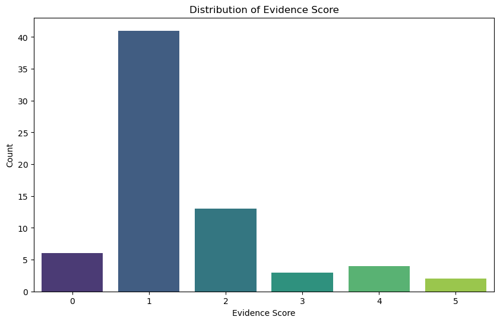

```python
plt.figure(figsize=(10, 6))
sns.countplot(x='evidence_score', data=c_b, palette='viridis')
plt.title('Distribution of Evidence Score')
plt.xlabel('Evidence Score')
plt.ylabel('Count')
plt.show()
```

The plot above shows distribution of the evidence_score across the dataset.The vast majority of health issues have a score of 1, suggesting either no or not enough proof for the effectiveness of cannabis or CBD. Additionally, a notable quantity of conditions carry a score of 0, indicating that cannabis or CBD might be detrimental. A very small percentage of conditions have a score higher than 2, suggesting that there's only a small amount of strong evidence supporting the use of cannabis or CBD for treating various health issues.

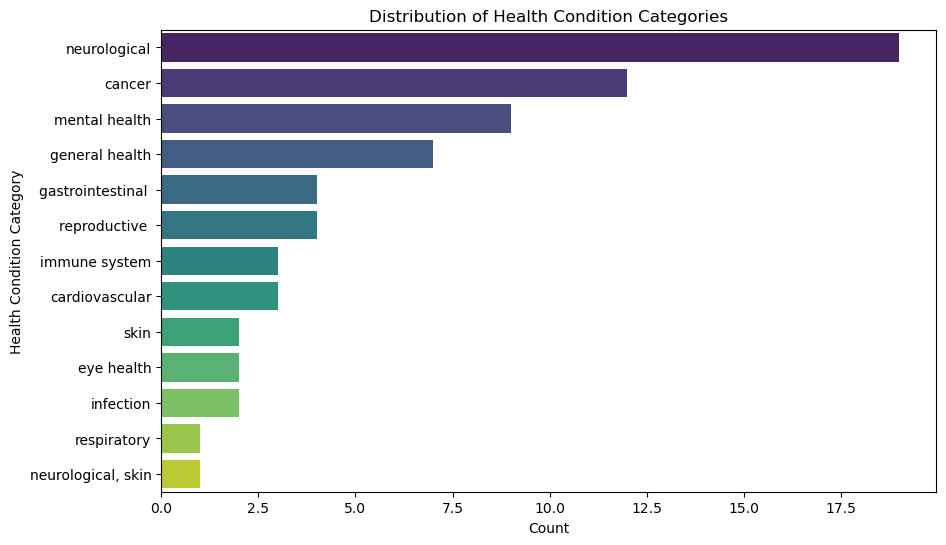

```python
plt.figure(figsize=(10, 6))
sns.countplot(y='health condition.1', data=c_b, palette='viridis', order=c_b['health condition.1'].value_counts().index)
plt.title('Distribution of Health Condition Categories')
plt.xlabel('Count')
plt.ylabel('Health Condition Category')
plt.show()
```

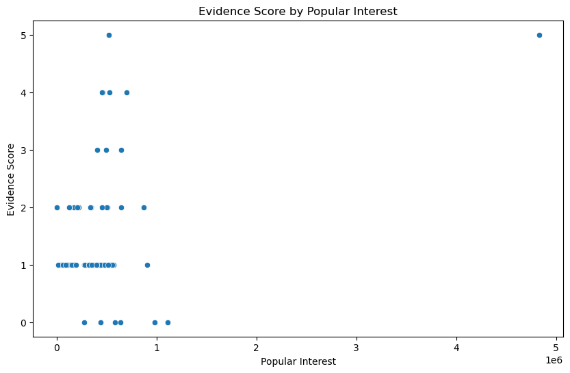

```python
plt.figure(figsize=(10, 6))
sns.scatterplot(x='popular interest', y='evidence_score', data=c_b, palette='viridis')
plt.title('Evidence Score by Popular Interest')
plt.xlabel('Popular Interest')
plt.ylabel('Evidence Score')
plt.show()
```

Observation for above plot link between evidence_score by popular interest

A group of things have a lot of people wanting them for treatment but not a lot of evidence to support their effectiveness (fewer than 1). This suggests that many things are popular for treating with cannabis or CBD because people like them, but there's not enough scientific proof to back up how well they work.

On the other hand, only a few things have a lot of people wanting them and strong scientific proof that they work. This shows that there are a limited number of things for which both a large number of people believe in the benefits of using cannabis or CBD, and there's solid scientific evidence to support this.

In summary, the graph shows that how much people like cannabis or CBD as a treatment doesn't always match up with how strong the evidence is that it works.

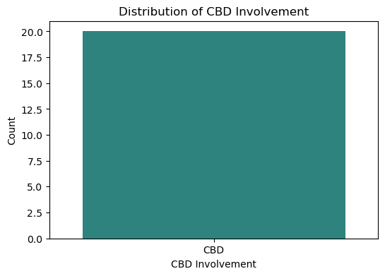

```python
plt.figure(figsize=(6, 4))
sns.countplot(x='CBD', data=c_b, palette='viridis')
plt.title('Distribution of CBD Involvement')
plt.xlabel('CBD Involvement')
plt.ylabel('Count')
plt.show()
```

The plot depicts the spread of situations where CBD is used in therapy. Most situations listed in the data set do not make use of CBD for treatment, while a smaller subset of situations do incorporate CBD.

```python
strong_evidence_c_b = c_b[c_b['evidence_score'] >= 5]

# Display the conditions with strong evidence
strong_evidence_c_b[['health condition', 'health condition.1', 'evidence_score', 'simple English notes']]
```

|  | health condition | health condition.1 | evidence_score | simple English notes |
| --- | --- | --- | --- | --- |
| 41 | Insomnia | general health | 5 | Large studies have shown that cannabis compoun... |
| 50 | Multiple Sclerosis (MS) | neurological | 5 | 2 studies involving a total of 790 subjects sh... |

In the dataset, there are two health issues for which there's substantial proof (evidence_score >= 5) supporting the effectiveness of either cannabis or CBD:

Insomnia:This situation belongs to the broad health group. Extensive research has demonstrated that components of cannabis can cut down the duration needed for sleep and enhance the overall quantity of rest. Multiple Sclerosis(MS): This situation is categorized under the nervous system area. Two research projects, each involving a total of 790 individuals, demonstrated that compounds from cannabis significantly decreased muscle tightness and discomfort in individuals with MS. In this dataset, only two criteria show clear proof that cannabis or CBD works well. For the majority of the other health issues, the proof is either not enough or suggests that cannabis or CBD doesn't work.

```python
no_evidence_c_b = c_b[c_b['evidence_score'] == 1]

# Display the first few conditions with no or insufficient evidence
no_evidence_c_b[['health condition', 'health condition.1', 'evidence_score', 'simple English notes']].head()
```

|  | health condition | health condition.1 | evidence_score | simple English notes |
| --- | --- | --- | --- | --- |
| 0 | ADD/ADHD | mental health | 1 | Animal studies show improved social behaviour ... |
| 4 | Alzheimer’s | neurological | 1 | No human studies yet. |
| 8 | Autism | neurological | 1 | Might have some positive impact on autism-type... |
| 9 | Autoimmune Disease | immune system | 1 | Potential treatment for autoimmune diseases, s... |
| 10 | Bipolar Disorder | mental health | 1 | Possibly might help. But no conclusive studies... |

The following health ailments listed in the dataset either lack or have not enough supporting data (evidence_score = 1) on the effectiveness of cannabis or CBD.

ADD/ADHD: This disorder is categorized within mental health studies. Research conducted on animals indicates better social interaction and memory capabilities, though the evidence from studies on humans is insufficient.

Alzheimer’s: This disorder is categorized within the neurological field, with no human research available at this time.

Autism: This disorder is also categorized within the neurological field. The use of cannabis may have some beneficial effects on behaviors related to autism, though the evidence is not conclusive.

Autoimmune Disease: This condition is categorized under the immune system in studies. Cannabis shows potential for treating autoimmune diseases, like rheumatoid arthritis, although the evidence is not yet strong.

Bipolar Disorder: This disorder is classified as a mental health condition. Although there is potential for cannabis use to assist with this disorder, research has not yet provided clear-cut evidence.

```python
harmful_c_b = c_b[c_b['evidence_score'] == 0]

# Display the conditions for which cannabis or CBD is harmful
harmful_c_b[['health condition', 'health condition.1', 'evidence_score', 'simple English notes']]
```

|  | health condition | health condition.1 | evidence_score | simple English notes |
| --- | --- | --- | --- | --- |
| 1 | Adolescence | neurological | 0 | Use during teenage years appears to affect imp... |
| 7 | Asthma | respiratory | 0 | Smoking cannabis immediately expands the airwa... |
| 20 | Depression | mental health | 0 | No evidence it relieves depression. Heavy use ... |
| 27 | Fertility | reproductive | 0 | Reduces fertility in both men and women. That ... |
| 60 | Schizophrenia | mental health | 0 | Does not seem to reduce psychotic symptoms. In... |
| 63 | Stroke | cardiovascular | 0 | Numerous case reports & population studies sho... |

Here are the health issues from the data set where the use of cannabis or CBD is thought to be detrimental, based on the evidence score (evidence_score = 0):

Adolescence: This situation is categorized in neuroscience. Using marijuana during the teenage period is thought to impact one's ability to control impulses, retain information, and focus. Asthma: This situation is categorized in the respiratory system. Smoking marijuana temporarily widens the airways, but soon leads to severe narrowing of the bronchi. Depression: This situation is categorized in mental health. Research shows that there's no proof that marijuana can alleviate depression. In fact, excessive use may even exacerbate depression. Fertility: This situation is categorized in reproduction. Marijuana use reduces the ability to conceive in both men and women. Schizophrenia: This situation is categorized in mental health. There is evidence that marijuana does not improve symptoms of psychosis and may even increase the chance of developing psychosis. Stroke: This situation is categorized in the cardiovascular system. Several case studies and large-scale studies suggest that using marijuana is linked to an increased risk of stroke. These examples show that the effects of cannabis or CBD are not consistent and can pose risks for some health conditions.

Observation:

Inadequate Strong Proof: The effectiveness of cannabis or CBD in treating various health issues is backed by only two conditions: Insomnia and Multiple Sclerosis (MS), with substantial evidence (evidence_score >= 5) for both.

Negative Consequences: In certain health issues, the use of cannabis or CBD is deemed negative (evidence_score = 0). This encompasses conditions such as Adolescence, Asthma, and Depression.

Variation among Types: The evidence for the effectiveness or harm of cannabis or CBD in treating different types of health conditions is notably broad, with no definitive pattern of effectiveness or harm across all categories.

CBD Use: The vast majority of conditions in the dataset do not involve CBD in their treatment, with only a few exceptions.

It's important to remember that this review is based on the data available up to 2017, and new studies may have been conducted since then. Moreover, the legal status of cannabis and CBD varies by location, which could impact their accessibility and use for medical purposes.

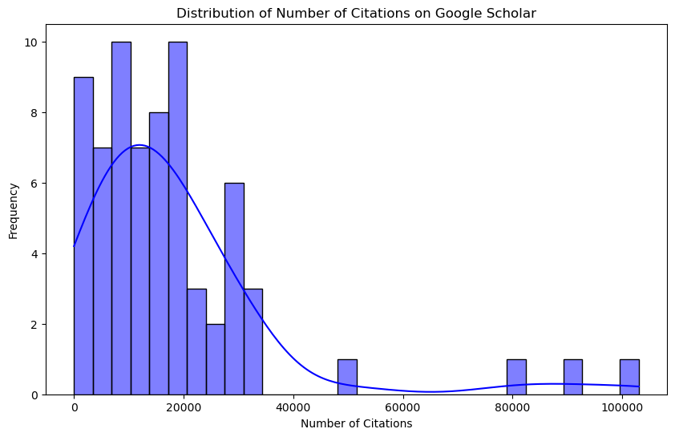

```python
plt.figure(figsize=(10, 6))
sns.histplot(c_b['Number of citations on Google Scholar (2000-2017) search format: condition+cannabis'], kde=True, bins=30, color='b')
plt.title('Distribution of Number of Citations on Google Scholar')
plt.xlabel('Number of Citations')
plt.ylabel('Frequency')
plt.show()
```

And that's it—our examination of the data set is complete. We've looked into how evidence is distributed, the categories of health conditions, the level of public interest, the role of CBD, the quality and quantity of evidence, and the count of references on Google Scholar

In Conclusion:

Conclusive Proof: Research strongly supports the use of cannabis or CBD for just a select few health issues, mainly Insomnia and MS.

Incomplete Proof: Most of the health conditions listed do not have conclusive proof regarding the effectiveness of cannabis or CBD.

Serious Risks: Health issues like Adolescence, Asthma, and Depression are linked to serious risks with the use of cannabis or CBD.

Differences Among Types: The proof of effectiveness for cannabis or CBD varies greatly within different types of health conditions.

Public Demand vs. Research Proof: There's no obvious link between what's popular and the robustness of research in support of cannabis or CBD's effectiveness.

CBD Use: A limited number of health conditions benefit from the use of CBD for treatment.

Research References: The count of references in Google Scholar for studies about the condition and its relation to cannabis or CBD ranges from low to high, reflecting various research levels and interests in the scientific community for different health conditions and cannabis-related research.

It's crucial to proceed with caution when considering the use of cannabis or CBD for medical reasons, taking into account the current scientific evidence, possible adverse effects, and legalities within your area.